# Test_a_Perceptual_PhenomenonUdacity2June2018

### Analyzing the Stroop Effect

Perform the analysis in the space below. Remember to follow [the instructions](https://docs.google.com/document/d/1-OkpZLjG_kX9J6LIQ5IltsqMzVWjh36QpnP2RYpVdPU/pub?embedded=True) and review the [project rubric](https://review.udacity.com/#!/rubrics/71/view) before submitting. Once you've completed the analysis and write-up, download this file as a PDF or HTML file, upload that PDF/HTML into the workspace here (click on the orange Jupyter icon in the upper left then Upload), then use the Submit Project button at the bottom of this page. This will create a zip file containing both this .ipynb doc and the PDF/HTML doc that will be submitted for your project.

(1) What is the independent variable? What is the dependent variable?

The independent variable is - word and color match: congruent example - blue, incongruent example - blue  
The dependent variable is - population mean response time

(2) What is an appropriate set of hypotheses for this task? Specify your null and alternative hypotheses, and clearly define any notation used. Justify your choices.

μ<sub>c</sub> - congruent population mean response time  
μ<sub>i</sub> - incongruent population mean response time

H<sub>0</sub> : μ<sub>c</sub>- μ<sub>i</sub> $\geq$ 0 - null hypothesis - incongruent population mean response time is not statistically significantly longer  
H<sub>1</sub> : μ<sub>c</sub>- μ<sub>i</sub> $\lt$ 0 - alternative hypothesis - incongruent population mean response time is statistically significantly longer

(3) Report some descriptive statistics regarding this dataset. Include at least one measure of central tendency and at least one measure of variability. The name of the data file is 'stroopdata.csv'.

```python
# Perform the analysis here
import os
import sys
import platform
from scipy.stats import mode
import csv
import pandas as pd
import math

# local environment information
print("\nsys.version - {}".format(sys.version))
print("platform.python_version() - {}".format(platform.python_version()))
print("pd.__version__ - {}\n".format(pd.__version__))

# get the data
DATADIR = '/Users/menfisystems/Documents/mike/Term2DAND/percepPhenom'
DATAFILE = 'stroopdata.csv'
stroop_data_csv  = os.path.join(DATADIR, DATAFILE)

# used during software developement
with open(stroop_data_csv, newline='') as csvfile:
    myFile = csv.reader(csvfile)
    for row in myFile:
        # print(row)
        pass
# used during software developement

stroopData = pd.read_csv(stroop_data_csv)
# DataFrame
print("type(stroopData).__name__ - {}".format(type(stroopData).__name__))
print('type(stroopData) = {}\n'.format(type(stroopData)))

# Series
print("type(stroopData['Congruent']).__name__ - {}".format(type(stroopData['Congruent']).__name__))
print("type(stroopData['Congruent']) = {}\n".format(type(stroopData['Congruent'])))

# central tendency
print("stroopData['Congruent'].mean() - {}".format(stroopData['Congruent'].mean()))
print("stroopData['Incongruent'].mean() - {}".format(stroopData['Incongruent'].mean()))

# central tendency
print("stroopData['Congruent'].median() - {}".format(stroopData['Congruent'].median()))
print("stroopData['Incongruent'].median() - {}\n".format(stroopData['Incongruent'].median()))

# central tendency
# DataFrame frame, series mode not applicable, all series values occur only once
# print("stroopData.mode() - {}".format("stroopData.mode()"))
# print(stroopData.mode())

# variability
print("stroopData['Congruent'].std()")
print(stroopData['Congruent'].std())
print()

# variability
print("stroopData['Incongruent'].std()")
print(stroopData['Incongruent'].std())
print()
```

```
sys.version - 3.6.3 |Anaconda custom (64-bit)| (default, Oct  6 2017, 12:04:38)
[GCC 4.2.1 Compatible Clang 4.0.1 (tags/RELEASE_401/final)]
platform.python_version() - 3.6.3
pd.__version__ - 0.20.3

type(stroopData).__name__ - DataFrame
type(stroopData) = <class 'pandas.core.frame.DataFrame'>

type(stroopData['Congruent']).__name__ - Series
type(stroopData['Congruent']) = <class 'pandas.core.series.Series'>

stroopData['Congruent'].mean() - 14.051125000000004
stroopData['Incongruent'].mean() - 22.01591666666667
stroopData['Congruent'].median() - 14.3565
stroopData['Incongruent'].median() - 21.0175

stroopData['Congruent'].std()
3.559357957645195

stroopData['Incongruent'].std()
4.797057122469138
```

Include at least one measure of central tendency ...  
stroopData['Congruent'].mean() - 14.051125000000004  
stroopData['Incongruent'].mean() - 22.01591666666667

stroopData['Congruent'].median() - 14.3565  
stroopData['Incongruent'].median() - 21.0175

DataFrame frame, series mode not applicable, all series values occur only once.

Variability  
stroopData['Congruent'].std() 3.559357957645195  
stroopData['Incongruent'].std() 4.797057122469138

(4) Provide one or two visualizations that show the distribution of the sample data. Write one or two sentences noting what you observe about the plot or plots.

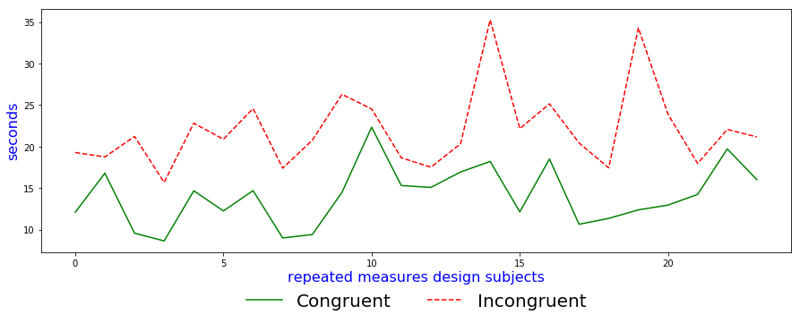

```python
plt.rcParams["figure.figsize"] = [15,5]
fig, ax = plt.subplots()

ax.plot(stroopData.Congruent,'g')
ax.plot(stroopData.Incongruent,'--r')

ax.legend(frameon=False, loc=9, bbox_to_anchor=(0.5,-0.1), ncol = 4, prop={'size': 20})

plt.xlabel('repeated measures design subjects', fontsize=16, color = 'blue')
plt.ylabel('seconds', fontsize=16, color = 'blue')

plt.show()
```

Visualization indicates Incongruent times trend greater than Congruent times.

Udacity reviewer -  
I see that you used Dependent t-test for this test, which is correct. But please have a section explicitly state that you are using dependent/paired t-test.

Using dependent/paired t-test. This is a within subject design, repeated measures design test. Each subject exposed to Congruent and Incongruent test in random order.

Udacity reviewer -  
Also please state the assumptions made by the test in terms of normality, sample size, why paired t-test.  
Psychological experiments typicaly approximate a normal distribution. Our small sample size increses our margin of error, and increases the range of out Confidence Level.  
Why paired t-test?  
Paired t test because this was a within subject design, repeated mesures design investigation. Population paramters not known Z test not indicated.

```python
# Dependent t-test

print("\nstroopData['Congruent'].mean() - {}".format(stroopData['Congruent'].mean()))
print("stroopData['Incongruent'].mean() - {}\n".format(stroopData['Incongruent'].mean()))

t_numerator = stroopData['Congruent'].mean() - stroopData['Incongruent'].mean()
print("t_numerator  - {}\n".format(t_numerator ))

stroopData['Con-Incon'] = stroopData.Congruent - stroopData.Incongruent
time_diff_std_dev = stroopData['Con-Incon'].std()
# print(stroopData.head()) # used for software development
print("time_diff_std_dev - {}\n".format(time_diff_std_dev))

t_denominator = ( time_diff_std_dev / math.sqrt(24) )
print("t_denominator - {}\n".format(t_denominator))

t_statistic = t_numerator / t_denominator

print("t_statistic - {}".format(t_statistic))
```

```
stroopData['Congruent'].mean() - 14.051125000000004
stroopData['Incongruent'].mean() - 22.01591666666667

t_numerator  - -7.964791666666665

time_diff_std_dev - 4.864826910359056

t_denominator - 0.9930286347783406

t_statistic - -8.020706944109955
```

(6) Optional: What do you think is responsible for the effects observed? Can you think of an alternative or similar task that would result in a similar effect? Some research about the problem will be helpful for thinking about these two questions!